# Mobile App Rating Prediction

## Lets now restrict our model to only look at the top 20 features

```r
df<-data.frame(dummy_Train)
top20<-df[c("Reviews", "Size", "Current.Ver", "Installs", "Android.Ver", "Price", "CategoryFAMILY", "CategoryTOOLS", "CategoryHEALTH_AND_FITNESS", "CategoryMEDICAL", "CategoryFINANCE", "CategoryLIFESTYLE", "CategoryBUSINESS", "CategoryPHOTOGRAPHY", "Content.RatingEveryone", "CategorySPORTS", "CategoryDATING", "CategoryNEWS_AND_MAGAZINES", "CategoryPRODUCTIVITY", "CategoryGAME")]

set.seed(742)

rf_Model2<-randomForest(top20,train_y, ntree=100, max_nodes = 1000, importance = T)

importance(rf_Model2)
```

```
##                               %IncMSE IncNodePurity
## Reviews                    22.7783696     368.23170
## Size                       10.0656973     240.92216
## Current.Ver                 2.7392884     183.94021
## Installs                   13.8802020     169.41517
## Android.Ver                 4.7282439     112.04730
## Price                       8.4030324      37.65138
## CategoryFAMILY              3.3480765      26.67148
## CategoryTOOLS               7.5406433      20.41303
## CategoryHEALTH_AND_FITNESS  7.7825709      19.53528
## CategoryMEDICAL            -0.3386203      19.01266
## CategoryFINANCE             1.9870561      17.03417
## CategoryLIFESTYLE           1.8099343      18.24537
## CategoryBUSINESS           -0.9866024      16.61660
## CategoryPHOTOGRAPHY         3.2645059      14.80989
## Content.RatingEveryone      3.3531650      21.75828
## CategorySPORTS              2.6748542      13.83572
## CategoryDATING              6.2063912      17.34750
## CategoryNEWS_AND_MAGAZINES -0.9815341      12.55627
## CategoryPRODUCTIVITY       -2.2660374      13.29978
## CategoryGAME                5.2892386      13.38679
```

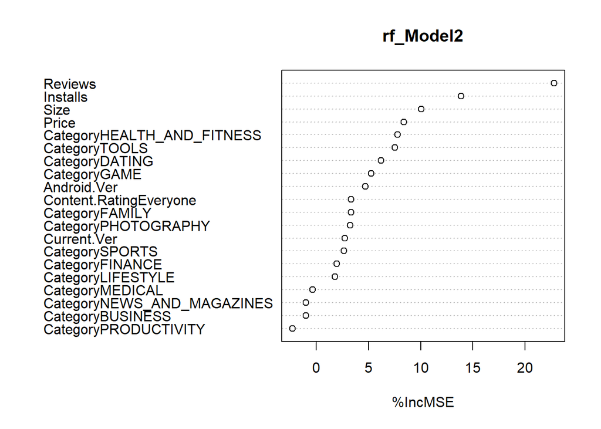

```r
varImpPlot(rf_Model2, type = 1)
```

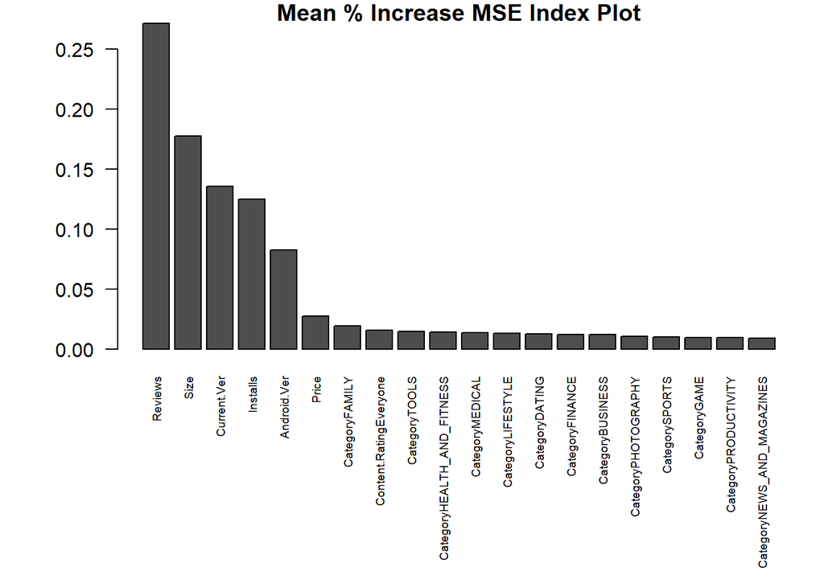

```r
var.imp1 <- data.frame(importance(rf_Model2, type=2))
var.imp1$Variables <- row.names(var.imp1)
varimp1 <- var.imp1[order(var.imp1[1],decreasing = T),]
par(mar=c(10,5,1,1))
giniplot <- barplot(t(varimp1[-2]/sum(varimp1[-2])),las=2,
                     cex.names=0.6,
                    main="Mean % Increase MSE Index Plot")
```

## Everything looks ok now lets check the accuracy measures

```r
new_preds<- predict(rf_Model2, top20)
rmse(train_y, new_preds)
```

```
## [1] 0.2732067
```

```r
new_pred_pop<-c()

for(i in seq(length(train_y))){
  if(new_preds[i]<3.5){
    new_pred_pop<-append(new_pred_pop,"Bad")
  }
  else{
    new_pred_pop<-append(new_pred_pop,"Popular")
  }
}

table(true_pop,new_pred_pop)
```

```
##          new_pred_pop
## true_pop   Bad Popular
##   Bad      203     312
##   Popular    4    6039
```

```r
203/(203+312)
```

```
## [1] 0.3941748
```

```r
(6039+203)/(203+312+6039+4)
```

```
## [1] 0.9518146
```

## We can see that our overall accuracy is relatively unchanged (still 95%) and the rmse has only gone up slightly meaning our reduction in features was waranted, however we can see that the model is now worse at predicting low review scores, down to 39.4% from about 50% accuracy earlier

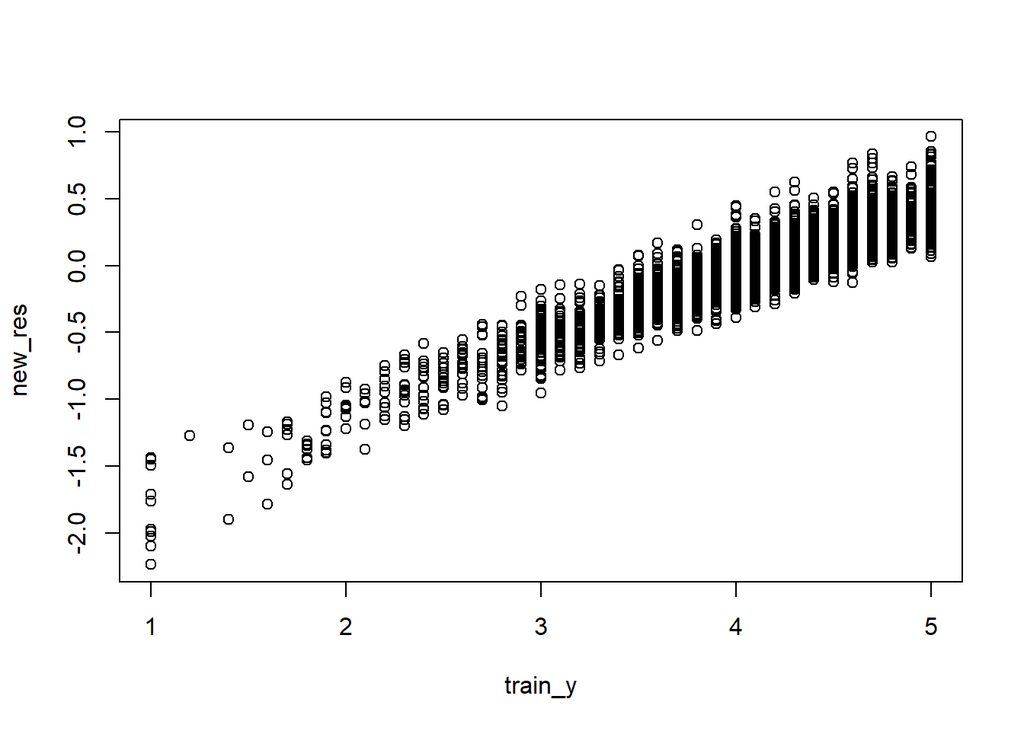

```r
new_res<-train_y-new_preds
plot(train_y,new_res)
```

# After thinking about the possible ways to improve this I have come up with a new solution:

## First I will develop a classifier to predict whether the rating will be bad or good, then depending on the classification, I will use a second model to predict the rating score, so we will have 3 total models, 1 model will be the classifier, 1 model will be the regressor on poor performing apps, and the 3rd model will be the predictor on high performing apps. I will build a function to run the initial classification then select the appropriate regressor model based on the classification.

## We will need to select the appropriate predictors for all 3 models so we will start from the original dummy variable matrix in all 3 cases.

# Building the classifier:

### Note we need to use the true_pop as our response variable in this case

```r
set.seed(888)
true_pop<-as.factor(true_pop)
pop_classifier<-randomForest(dummy_Train,true_pop, ntree=100, max_nodes = 1000, importance = T)

importance(pop_classifier)
```

```
##                                    Bad    Popular MeanDecreaseAccuracy MeanDecreaseGini
## (Intercept)                  0.0000000  0.0000000            0.0000000        0.0000000
## CategoryAUTO_AND_VEHICLES    3.1434064  0.3635213            1.3072871        1.8890045
## CategoryBEAUTY               0.0000000 -0.6751981           -0.6809445        0.9079845
## CategoryBOOKS_AND_REFERENCE -0.9040307 -0.5456080           -0.7653131        3.2225905
## CategoryBUSINESS             1.2532987 -1.4848791           -0.6897120        7.4416010
## CategoryCOMICS               4.1787536 -1.2220359            0.7406848        4.7598521
## CategoryCOMMUNICATION       -1.5851599  0.9051400            0.3988777        4.2103038
## CategoryDATING               3.6609382  1.4283487            2.9239115        4.4921836
## CategoryEDUCATION            2.1599073  0.3074192            1.2198986        0.4926594
## CategoryENTERTAINMENT       -2.2920233  3.1631689            2.9067014        1.9619500
## CategoryEVENTS              -0.5701448 -0.2387210           -0.4238254        0.6578095
## CategoryFAMILY               1.5307426  3.1300661            3.6932832        8.4993392
## CategoryFINANCE              0.5376942  1.7935697            1.8766433        5.5277159
## CategoryFOOD_AND_DRINK       0.7929218 -0.2359763            0.1652157        4.0682121
## CategoryGAME                 2.6921505  0.7078772            1.6747919        4.8598047
## CategoryHEALTH_AND_FITNESS   3.5180575  4.3019349            5.5648107        6.1874343
## CategoryHOUSE_AND_HOME      -2.7668380  0.5756513           -0.5389683        2.0055952
## CategoryLIBRARIES_AND_DEMO   0.9448641  1.9853608            2.1119854        2.5752662
## CategoryLIFESTYLE            2.6713278  0.3687939            1.4250451        6.2660924
## CategoryMAPS_AND_NAVIGATION  4.1587115  0.4965343            2.2248814        5.3722517
## CategoryMEDICAL             -0.1741456  2.7567366            2.6418775        5.0849728
## CategoryNEWS_AND_MAGAZINES   0.5846641 -0.8487936           -0.6045030        4.7634241
## CategoryPARENTING            1.0050378  2.8591210            2.9060135        0.4280885
## CategoryPERSONALIZATION      2.6312756  1.3925114            2.2062522        2.6888200
## CategoryPHOTOGRAPHY          2.1604508  1.3126051            2.1521241        7.0763593
## CategoryPRODUCTIVITY         0.8512776  0.8082218            1.0152105        4.8925712
## CategorySHOPPING             0.3501516  1.4630528            1.6929705        2.2473540
## CategorySOCIAL               3.0241378  1.2433186            2.1064109        2.6064019
## CategorySPORTS               0.5966939 -1.1927730           -0.9124832        5.0830403
## CategoryTOOLS                4.4337394  2.2375274            3.6732394       10.1575870
## CategoryTRAVEL_AND_LOCAL     2.5376431  1.8147188            2.7183339        7.2321571
## CategoryVIDEO_PLAYERS        0.8597136  2.0441462            2.1551201        5.7692991
## CategoryWEATHER             -1.7571014  1.0054262            0.4043540        0.8856235
## Reviews                     13.3295991  9.9624647           11.0650634      118.2722370
## Size                        -2.7773705 10.0457587            9.3582059       78.7925207
## Installs                    -5.2925427 10.4543502           11.2117681       58.4485096
## Price                        2.7558250  2.0114459            2.8931486       12.0394622
## Content.RatingEveryone       3.5308750  2.5440603            3.7985464        5.3924136
## Content.RatingEveryone 10+  -0.5528740  1.0454608            0.8053278        2.1681754
## Content.RatingMature 17+     2.6943322 -0.3058621            0.7849511        3.7393911
## Content.RatingTeen           0.9728247  1.6294910            1.8871447        4.2828455
## Content.RatingUnrated        0.0000000  0.0000000            0.0000000        0.0105181
## Current.Ver                 -0.5024076  4.8053179            4.7338181       59.3702077
## Android.Ver                 -0.5541077  7.6841928            7.5094624       41.7815242
## Days                         6.9283863 -0.5201248            2.0576596       83.3234368
```

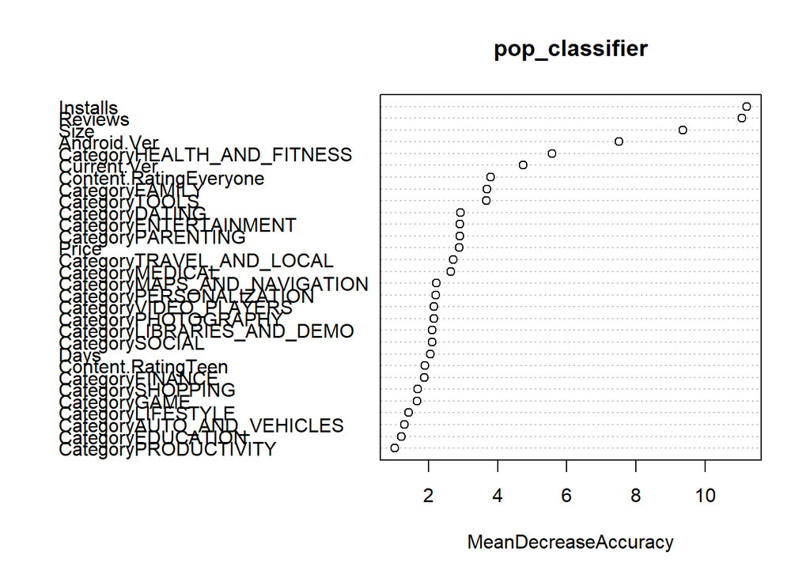

```r
varImpPlot(pop_classifier, type = 1)
```

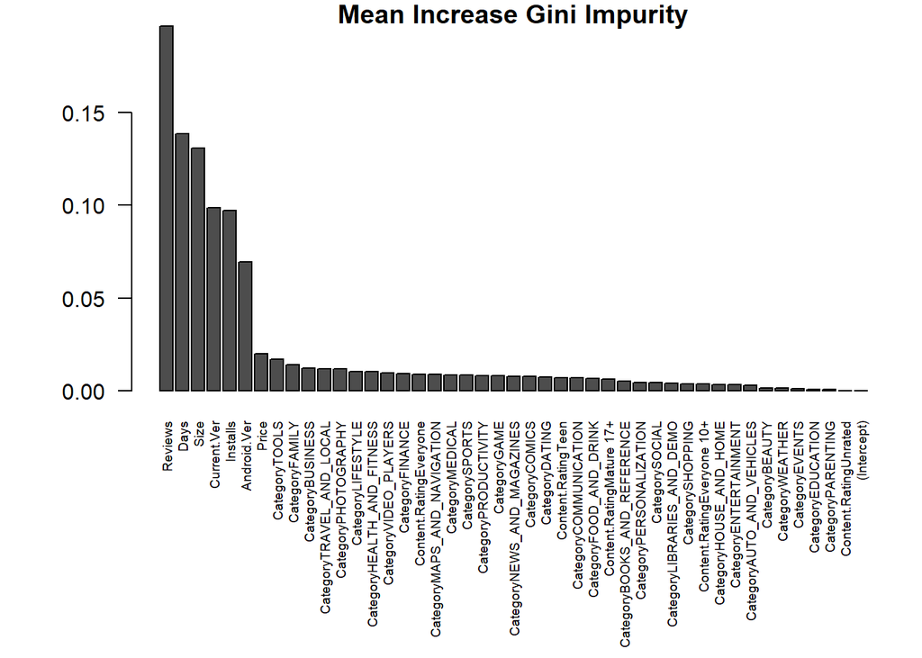

```r
var.imp1 <- data.frame(importance(pop_classifier, type=2))
var.imp1$Variables <- row.names(var.imp1)
varimp1 <- var.imp1[order(var.imp1[1],decreasing = T),]
par(mar=c(10,5,1,1))
giniplot <- barplot(t(varimp1[-2]/sum(varimp1[-2])),las=2,
                     cex.names=0.6,
                    main="Mean Increase Gini Impurity")
```

```r
clas_preds<-predict(pop_classifier, dummy_Train)

table(true_pop,clas_preds)
```

```
##          clas_preds
## true_pop   Bad Popular
##   Bad      141     374
##   Popular    0    6043
```

## This model is quite bad at predicting due to the imbalance of the class sizes, we can however use the classwt option in random forest to improve the importance of classifying bad apps. We can use this to set the predicted class size proportions

```r
set.seed(888)

pop_classifier<-randomForest(dummy_Train,true_pop, ntree=100, max_nodes = 1000, importance = T, classwt = c(0.20, 0.80))

importance(pop_classifier)
```

```
##                                    Bad      Popular MeanDecreaseAccuracy MeanDecreaseGini
## (Intercept)                  0.0000000  0.000000000          0.000000000       0.00000000
## CategoryAUTO_AND_VEHICLES    1.7383818  0.205205379          0.727134296       3.95224533
## CategoryBEAUTY              -0.5706177 -0.009878961         -0.133675287       2.04514445
## CategoryBOOKS_AND_REFERENCE -2.0700983 -0.127589668         -0.812625598       6.56766383
## CategoryBUSINESS             3.4707875 -1.938513881         -0.140369152      15.10728799
## CategoryCOMICS               6.4118580 -0.531509825          1.528844141       9.91245212
## CategoryCOMMUNICATION       -0.2874080  1.242555790          1.088708082       8.31945360
## CategoryDATING               4.4894483 -2.172730165         -0.598880595      10.95471574
## CategoryEDUCATION            3.6105660 -1.891233505         -0.360241992       2.60137070
## CategoryENTERTAINMENT       -2.4681776  3.112023927          2.672250834       3.93549027
## CategoryEVENTS               0.5966349 -0.161155534          0.003171344       1.54332031
## CategoryFAMILY               0.6548479  3.762247730          3.921526363      22.02527036
## CategoryFINANCE              1.4160285  1.235458942          1.641433542      13.25346286
## CategoryFOOD_AND_DRINK       2.7858473 -0.516424168          0.529363844       8.99695898
## CategoryGAME                 2.6373375 -1.176148089         -0.377492332      15.42478550
## CategoryHEALTH_AND_FITNESS   2.4038843  2.713895044          3.382293658      10.92024914
## CategoryHOUSE_AND_HOME      -2.2912349 -1.560695122         -2.098151599       3.37532970
## CategoryLIBRARIES_AND_DEMO   1.7504850  2.221899873          2.495123830       6.93322688
## CategoryLIFESTYLE            2.9783414 -2.170119739         -1.097296596      16.28663324
## CategoryMAPS_AND_NAVIGATION  4.9395664 -1.538109215          1.354966239      11.29946593
## CategoryMEDICAL             -0.8028444  3.447999145          3.144599485      12.16002272
## CategoryNEWS_AND_MAGAZINES   1.8673917 -1.811927607         -1.216025911      10.32859711
## CategoryPARENTING            2.0380301  3.422607062          3.601511225       1.69948176
## CategoryPERSONALIZATION      3.5411844  2.739258249          3.737592400       9.59366944
## CategoryPHOTOGRAPHY          1.5890139  4.257042383          4.825701171      13.88102688
## CategoryPRODUCTIVITY         2.5552481 -0.691252457          0.003869229      10.32477659
## CategorySHOPPING             0.6056246 -0.916426862         -0.679577794       5.49412063
## CategorySOCIAL              -0.8527608  1.883619612          1.497933598       4.77285239
## CategorySPORTS              -1.2087879 -1.890581236         -2.233807384       9.35534142
## CategoryTOOLS                6.6128450 -3.263342267         -0.933514542      26.10633073
## CategoryTRAVEL_AND_LOCAL     5.9193193  2.604117776          4.727527563      17.18836916
## CategoryVIDEO_PLAYERS        5.2276571  3.554631573          4.925938141      10.43575954
## CategoryWEATHER             -2.0408956  1.433724639          0.910125314       1.66511438
## Reviews                     22.2041781  7.448034193          9.711707800     352.46293190
## Size                         0.6296253  5.876927931          6.277270175     175.26809812
## Installs                    -1.0806949  7.071502838          8.054384364     176.50651758
## Price                        1.0935372  4.501711097          4.599952438      26.47551905
## Content.RatingEveryone       5.0479139 -1.527315789          0.695399275      14.34149225
## Content.RatingEveryone 10+   1.7828471 -0.942089631         -0.417037178       5.28718115
## Content.RatingMature 17+     3.2368965 -1.722403707         -0.512609606       8.50049387
## Content.RatingTeen           2.9340478 -1.869676014         -0.889368436      10.58450283
## Content.RatingUnrated        0.0000000  0.000000000          0.000000000       0.03038979
## Current.Ver                  1.7823193  1.231934875          1.649515010     135.66895197
## Android.Ver                  1.4307477  3.718501493          4.453160641      90.50944161
## Days                         6.1739867 -0.510494394          1.717804365     183.62776356
```

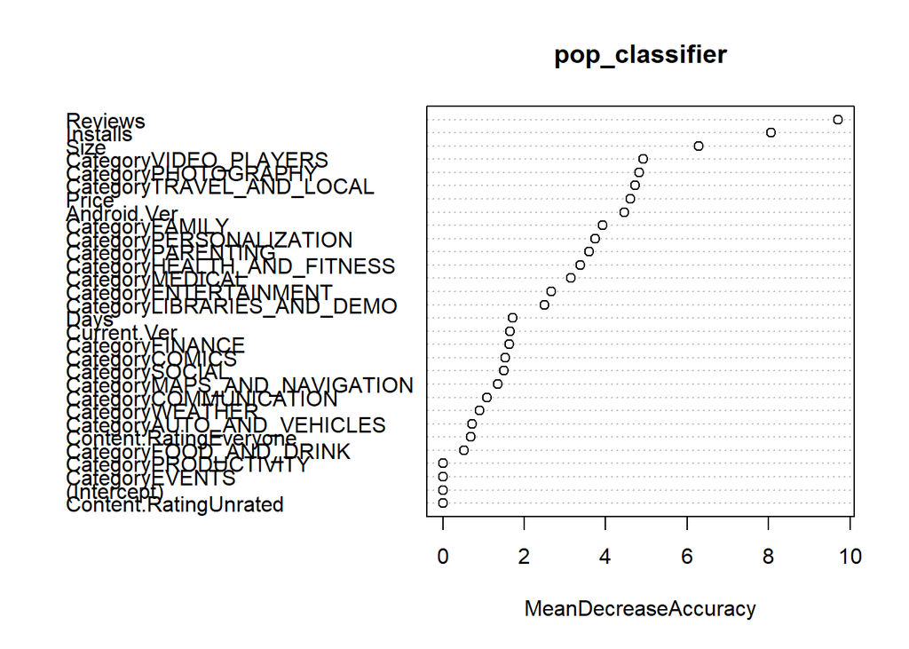

```r
varImpPlot(pop_classifier, type = 1)
```

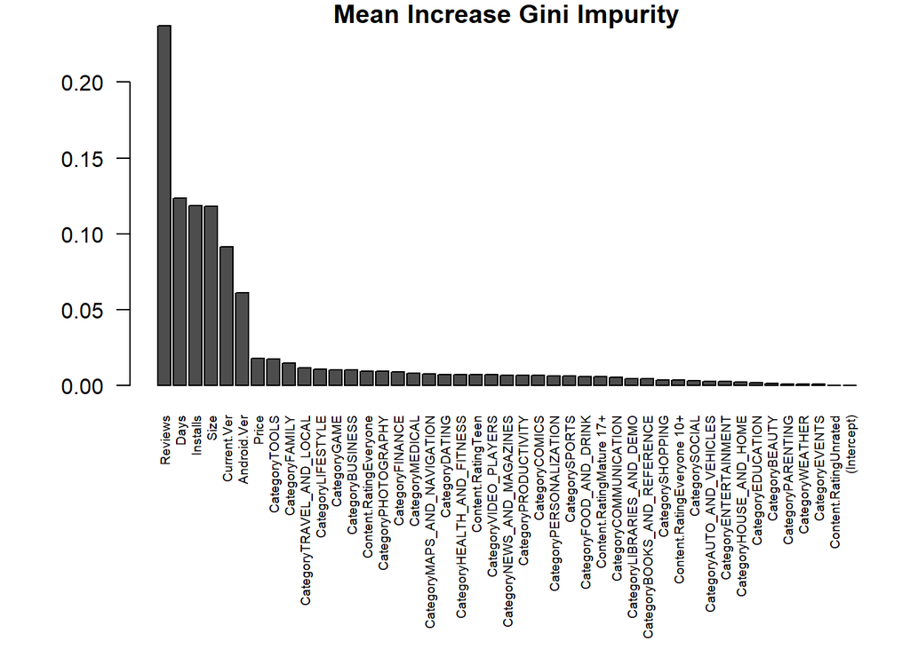

```r
var.imp1 <- data.frame(importance(pop_classifier, type=2))
var.imp1$Variables <- row.names(var.imp1)
varimp1 <- var.imp1[order(var.imp1[1],decreasing = T),]
par(mar=c(10,5,1,1))
giniplot <- barplot(t(varimp1[-2]/sum(varimp1[-2])),las=2,
                     cex.names=0.6,
                    main="Mean Increase Gini Impurity")
```

```r
clas_preds<-predict(pop_classifier, dummy_Train)

table(true_pop,clas_preds)
```

```
##          clas_preds
## true_pop   Bad Popular
##   Bad      358     157
##   Popular    2    6041
```

## I should also note that even if our model total accuracy goes down a bit as long as we can accurately predict most of the weaker scores the secondary models will correct for any previous mistakes if the group sizes are more similar I would like my classifier to acheive above 95% sensitivity on bad apps.

```r
set.seed(888)

pop_classifier<-randomForest(dummy_Train,true_pop, ntree=100, max_nodes = 1000, importance = T, classwt = c(0.60, 0.50))

importance(pop_classifier)
```

```
##                                     Bad    Popular MeanDecreaseAccuracy MeanDecreaseGini
## (Intercept)                  0.00000000  0.0000000            0.0000000       0.00000000
## CategoryAUTO_AND_VEHICLES   -3.14986060  4.4830819            3.0863721       7.09233011
## CategoryBEAUTY              -0.63120742  3.5252391            3.1506717       5.03062547
## CategoryBOOKS_AND_REFERENCE -5.83034282  5.1218005            2.8405289      12.20274337
## CategoryBUSINESS             2.67052411 -0.6031114            0.4476782      19.10244083
## CategoryCOMICS               3.65045868 -2.2469656           -0.4804469      13.31608896
## CategoryCOMMUNICATION       -1.95286877  1.2532411            0.1840098      10.55377890
## CategoryDATING               3.77124378 -2.9137924           -2.1111212      11.09527601
## CategoryEDUCATION            6.41749752 -3.2393384           -1.1749397      12.53567559
## CategoryENTERTAINMENT        0.79156866 -0.8237283           -0.6531403       7.84674675
## CategoryEVENTS               2.13578800  4.0425700            4.5471936       5.87209161
## CategoryFAMILY              -1.45284866 -2.8390827           -3.1451803      38.98072951
## CategoryFINANCE             -1.42155793  3.3692473            2.9829191      24.09119207
## CategoryFOOD_AND_DRINK       0.16531269 -3.1035764           -2.8862845      13.48515835
## CategoryGAME                 0.92512213  0.3317753            0.6137368      38.80820753
## CategoryHEALTH_AND_FITNESS   0.59004467  1.8089878            1.8230219      10.35560657
## CategoryHOUSE_AND_HOME      -2.35421240 -0.9340503           -1.6143660       5.02351842
## CategoryLIBRARIES_AND_DEMO   1.57450584  6.4035319            6.6537195      13.48346121
## CategoryLIFESTYLE            0.25707356  1.3786785            1.3694450      27.69316446
## CategoryMAPS_AND_NAVIGATION  2.67478808  1.1856773            2.1641535      10.45535814
## CategoryMEDICAL              0.07468822 -1.7055229           -1.8856000      18.61778965
## CategoryNEWS_AND_MAGAZINES  -3.26691849  0.7490304           -0.1359468      10.75551052
## CategoryPARENTING            3.90590805  7.0524063            7.6642417       7.82913001
## CategoryPERSONALIZATION      3.99854340  4.1009609            5.0811309      24.56933094
## CategoryPHOTOGRAPHY          0.33227901  1.9492958            1.9547275      12.52928289
## CategoryPRODUCTIVITY        -0.37150276  1.2818183            1.0713944      16.81389654
## CategorySHOPPING             3.97328969 -3.1188799           -1.8407793      13.96558009
## CategorySOCIAL               1.18044485 -2.1938143           -1.8034338       7.32281527
## CategorySPORTS              -0.54447156 -0.2324737           -0.4602662      14.75341185
## CategoryTOOLS               10.31907369 -5.9552339           -1.9905117      35.91300356
## CategoryTRAVEL_AND_LOCAL     3.59028104  1.4701774            2.8667170      16.52210756
## CategoryVIDEO_PLAYERS        0.75714484  1.6571460            1.7161458      12.64378084
## CategoryWEATHER             -0.33607300  0.6770541            0.4897692       3.21241716
## Reviews                     32.48124379 -1.7067814            3.0652436     740.04457988
## Size                         6.42785610 -2.8028003           -1.1436112     269.30864510
## Installs                     7.51822112 -3.6467429           -2.4215004     353.00095607
## Price                        0.58556096  6.6741995            6.4465992      46.10621863
## Content.RatingEveryone       5.32341074 -3.8231899           -2.9989490      27.75977222
## Content.RatingEveryone 10+   0.92148985 -2.0156700           -1.7450729      10.08510092
## Content.RatingMature 17+     4.89894477 -5.7426606           -4.8489615      10.90339659
## Content.RatingTeen           4.46904412 -3.1713196           -1.5675380      21.57487163
## Content.RatingUnrated        0.00000000  0.0000000            0.0000000       0.05375473
## Current.Ver                  1.73031902 -4.2982325           -4.1788455     197.81012467
## Android.Ver                  2.93423707 -3.4561867           -2.7840968     137.38629848
## Days                         2.01857077 -0.9316622           -0.2006989     281.62691059
```

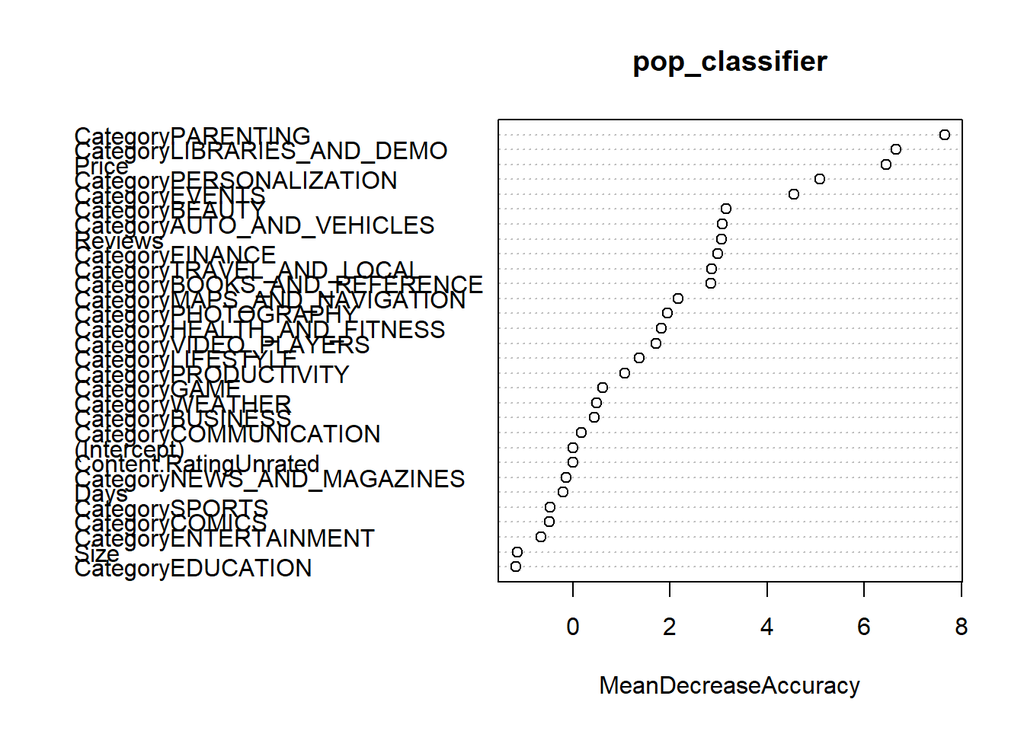

```r
varImpPlot(pop_classifier, type = 1)
```

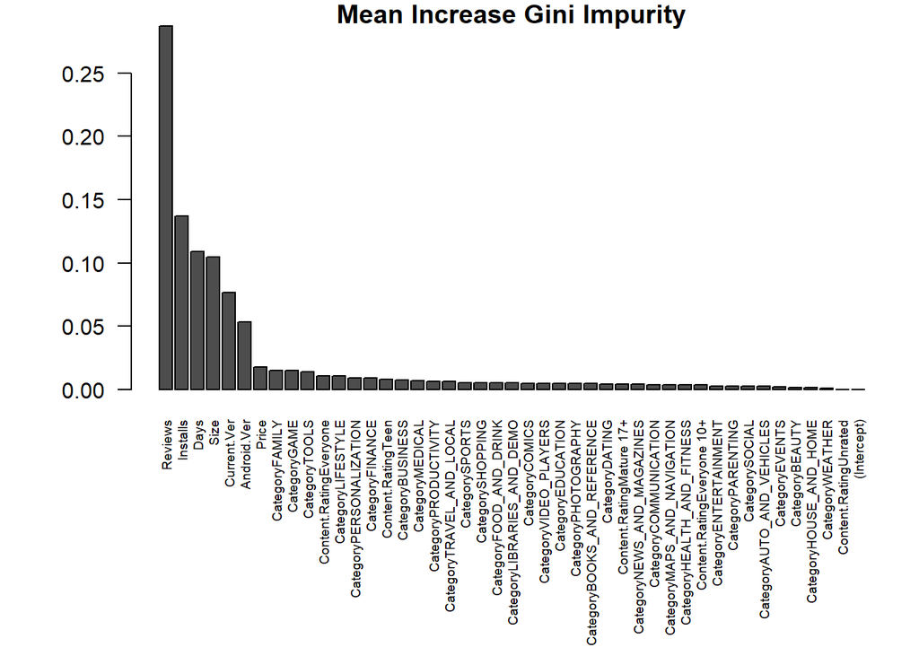

```r
var.imp1 <- data.frame(importance(pop_classifier, type=2))
var.imp1$Variables <- row.names(var.imp1)
varimp1 <- var.imp1[order(var.imp1[1],decreasing = T),]
par(mar=c(10,5,1,1))
giniplot <- barplot(t(varimp1[-2]/sum(varimp1[-2])),las=2,
                     cex.names=0.6,
                    main="Mean Increase Gini Impurity")
```

```r
clas_preds<-predict(pop_classifier, dummy_Train)

table(true_pop,clas_preds)
```

[output not shown]

```r
505/(505+10)
```

```
## [1] 0.9805825
```

## Now I will reduce the number of features in this model to avoid overfitting

## Top 20 Classification Features:

## 1. Reviews

## 2. Installs

## 3. Size

## 4. Current.Ver

## 5. Android.Ver

## 6. Price

## 7. CategoryFAMILY

## 8. CategoryTOOLS

## 9. CategoryGAME

## 10. CategoryLIFESTYLE

## 11. Content.RatingTeen

## 12. CategoryPERSONALIZATION

## 13. CategoryFINANCE

## 14. CategoryBUSINESS

## 15. CategoryMEDICAL

## 16. CategoryTRAVEL_AND_LOCAL

## 17. CategoryPRODUCTIVITY

## 18. CategoryFOOD_AND_DRINK

## 19. CategoryLIBRARIES_AND_DEMO

## 20. CategoryEDUCATION

```r
df<-data.frame(dummy_Train)
clas_top20<-df[c("Reviews","Installs","Size","Current.Ver","Android.Ver","Price","CategoryFAMILY","CategoryTOOLS","CategoryGAME","CategoryLIFESTYLE","Content.RatingTeen","CategoryPERSONALIZATION","CategoryFINANCE","CategoryBUSINESS","CategoryMEDICAL","CategoryTRAVEL_AND_LOCAL","CategoryPRODUCTIVITY","CategoryFOOD_AND_DRINK","CategoryLIBRARIES_AND_DEMO","CategoryEDUCATION")]

pop_classifier<-randomForest(clas_top20,true_pop, ntree=100, max_nodes = 1000, importance = T, classwt = c(0.60, 0.80))

importance(pop_classifier)
```

```
##                                   Bad    Popular MeanDecreaseAccuracy MeanDecreaseGini
## Reviews                    28.1700245  1.1918817          4.884413164        800.30941
## Installs                    6.3868513 -1.4908986         -0.440806647        408.54866
## Size                        3.4998808 -1.2813354         -0.386649522        354.17916
## Current.Ver                 2.2826042 -0.8021228         -0.283980634        258.46238
## Android.Ver                 4.4413716 -1.2095882          0.014275319        178.41539
## Price                       2.2127652  4.7067985          5.448178875         54.61367
## CategoryFAMILY             -2.0281547  2.3925658          2.023017003         44.25260
## CategoryTOOLS               6.2961682 -0.2472875          1.965043883         35.91773
## CategoryGAME                2.8785425  0.8476409          1.659036191         37.28430
## CategoryLIFESTYLE          -1.0300362  5.3291000          5.321039471         29.95790
## Content.RatingTeen          3.5738789 -4.8248528         -4.036509867         34.02697
## CategoryPERSONALIZATION     5.6793038  7.6687819          9.082950372         25.39257
## CategoryFINANCE            -2.4280620  5.1805637          4.522913109         24.81621
## CategoryBUSINESS            1.5056944 -0.6577014         -0.001612642         21.72796
## CategoryMEDICAL            -0.4318438  4.3017204          4.507949517         20.86831
## CategoryTRAVEL_AND_LOCAL    2.8385751  3.5198395          4.433335845         18.13844
## CategoryPRODUCTIVITY       -2.4551447  1.8370705          0.842973732         17.49513
## CategoryFOOD_AND_DRINK     -0.1496372  1.2082850          1.141153793         15.62942
## CategoryLIBRARIES_AND_DEMO  3.4471647  8.2779419          9.024823628         14.76445
## CategoryEDUCATION           7.1923038 -0.6782690          1.806831081         10.99037
```

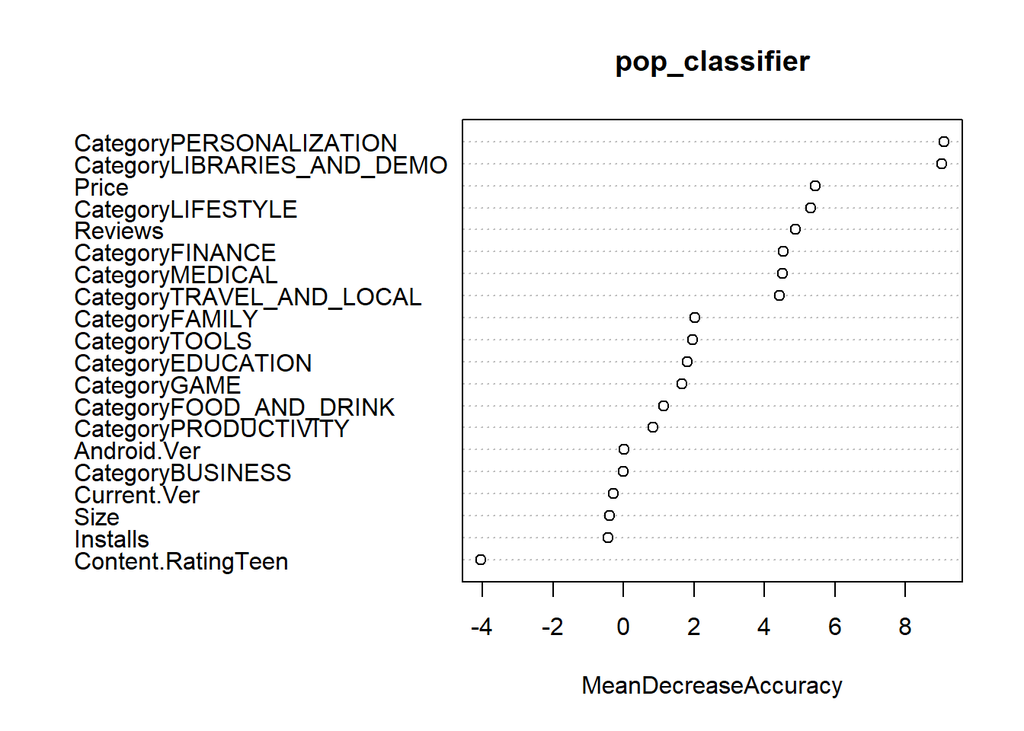

```r
varImpPlot(pop_classifier, type = 1)
```

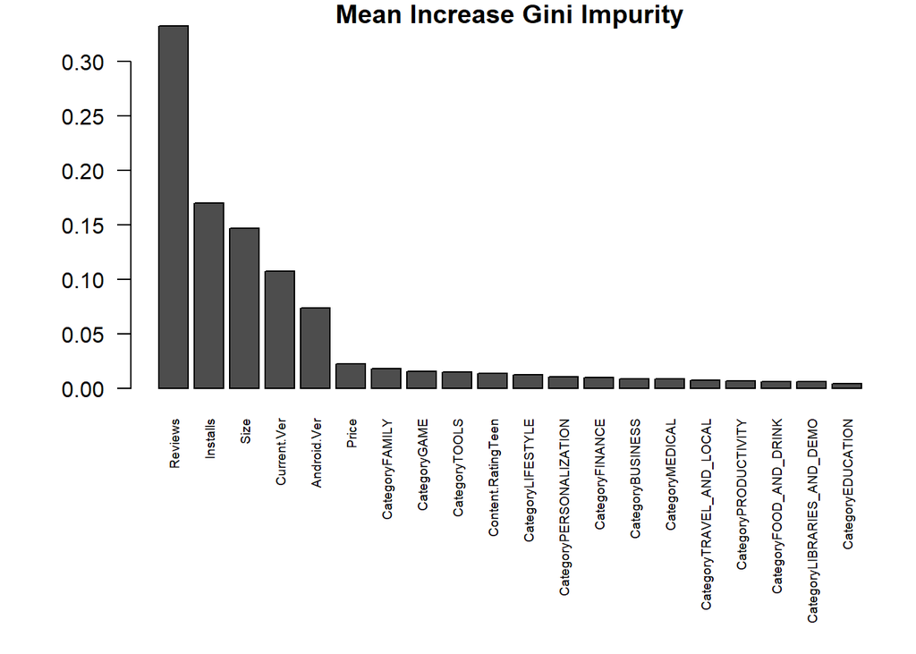

```r
var.imp1 <- data.frame(importance(pop_classifier, type=2))
var.imp1$Variables <- row.names(var.imp1)
varimp1 <- var.imp1[order(var.imp1[1],decreasing = T),]
par(mar=c(10,5,1,1))
giniplot <- barplot(t(varimp1[-2]/sum(varimp1[-2])),las=2,
                     cex.names=0.6,
                    main="Mean Increase Gini Impurity")
```

```r
clas_preds<-predict(pop_classifier, clas_top20)

table(true_pop,clas_preds)
```

```
##          clas_preds
## true_pop   Bad Popular
##   Bad      496      19
##   Popular  268    5775
```

# Now we will work on developing the two regressors to predict the actuall review score

## First we will split the data based on the true classes and then build a model on each subset

```r
lows<-which(true_pop == "Bad")
highs<-which(true_pop == "Popular")
low_dummy<-dummy_Train[lows,]
high_dummy<-dummy_Train[highs,]
low_rats<-train_y[lows]
high_rats<-train_y[highs]
```

## Building the model on the lower predicted class

```r
set.seed(742)

rf_Model_low<-randomForest(low_dummy,low_rats, ntree=100, max_nodes = 1000, importance = T)

importance(rf_Model_low)
```

```
##                                 %IncMSE IncNodePurity
## (Intercept)                  0.00000000   0.000000000
## CategoryAUTO_AND_VEHICLES   -0.89549214   0.512123748
## CategoryBEAUTY               0.00000000   0.015923649
## CategoryBOOKS_AND_REFERENCE  1.82651677   0.364601217
## CategoryBUSINESS            -1.54379454   1.031454720
## CategoryCOMICS              -0.21180950   0.114135132
## CategoryCOMMUNICATION       -2.07706164   1.883431942
## CategoryDATING               0.20389783   1.436091422
## CategoryEDUCATION            0.00000000   0.000000000
## CategoryENTERTAINMENT       -1.37763825   0.008760592
## CategoryEVENTS               0.00000000   0.002760462
## CategoryFAMILY              -0.21969977   2.332988382
## CategoryFINANCE             -0.30369946   2.090286917
## CategoryFOOD_AND_DRINK       1.64461171   1.455399888
## CategoryGAME                 0.42586582   0.734469884
## CategoryHEALTH_AND_FITNESS   3.32292039   1.672725438
## CategoryHOUSE_AND_HOME       1.16229452   0.098984388
## CategoryLIBRARIES_AND_DEMO   1.22654968   0.039856416
## CategoryLIFESTYLE            2.81855045   1.393008177
## CategoryMAPS_AND_NAVIGATION  1.16887552   0.322406999
## CategoryMEDICAL              1.85072375   2.551178895
## CategoryNEWS_AND_MAGAZINES   0.98132516   1.029690794
## CategoryPARENTING            0.00000000   0.000000000
## CategoryPERSONALIZATION     -0.87918812   0.052980271
## CategoryPHOTOGRAPHY          1.33335910   1.072643163
## CategoryPRODUCTIVITY         0.70420992   0.528771069
## CategorySHOPPING             0.68750230   0.673324235
## CategorySOCIAL              -2.68837716   0.439353750
## CategorySPORTS              -2.27878490   0.420353981
## CategoryTOOLS               -0.48347655   2.151206500
## CategoryTRAVEL_AND_LOCAL    -2.11956074   0.448724166
## CategoryVIDEO_PLAYERS       -1.99226160   0.336608795
## CategoryWEATHER              0.00000000   0.037878143
## Reviews                     11.34904282  32.285326775
## Size                         1.09554208  15.376074232
## Installs                     6.78071866  17.950733625
## Price                        3.18191435   1.930399727
## Content.RatingEveryone       1.43498831   1.160935875
## Content.RatingEveryone 10+   1.48762872   0.304043258
## Content.RatingMature 17+    -1.85987281   0.616616136
## Content.RatingTeen           1.68355444   0.950071425
## Content.RatingUnrated        0.00000000   0.000000000
## Current.Ver                  1.67885315  13.112560613
## Android.Ver                  2.23778182   7.829537449
## Days                         0.07839085  19.152264790
```

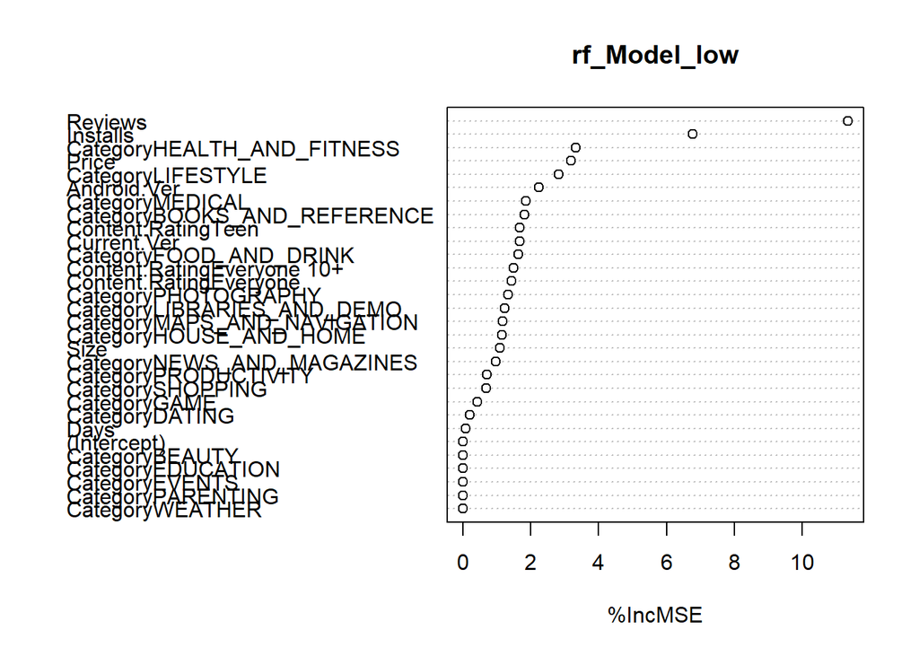

```r
varImpPlot(rf_Model_low, type = 1)
```

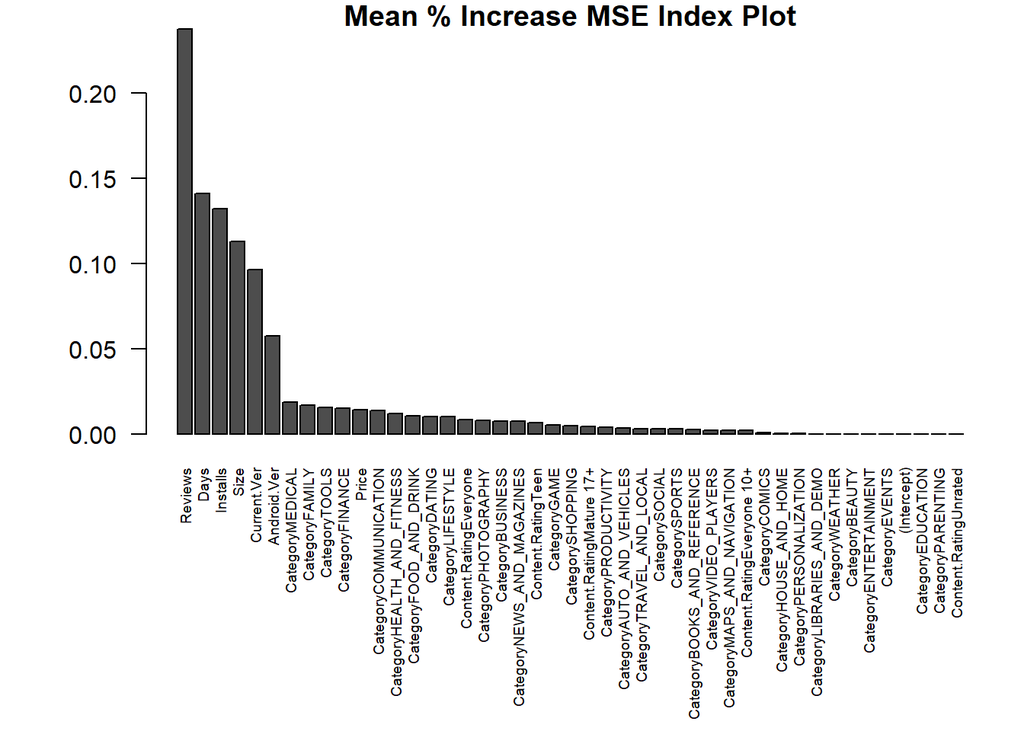

```r
var.imp1 <- data.frame(importance(rf_Model_low, type=2))
var.imp1$Variables <- row.names(var.imp1)
varimp1 <- var.imp1[order(var.imp1[1],decreasing = T),]
par(mar=c(10,5,1,1))
giniplot <- barplot(t(varimp1[-2]/sum(varimp1[-2])),las=2,
                     cex.names=0.6,
                    main="Mean % Increase MSE Index Plot")
```

```r
preds_low<- predict(rf_Model_low, low_dummy)

rmse(low_rats, preds_low)
```

```
## [1] 0.2335072
```

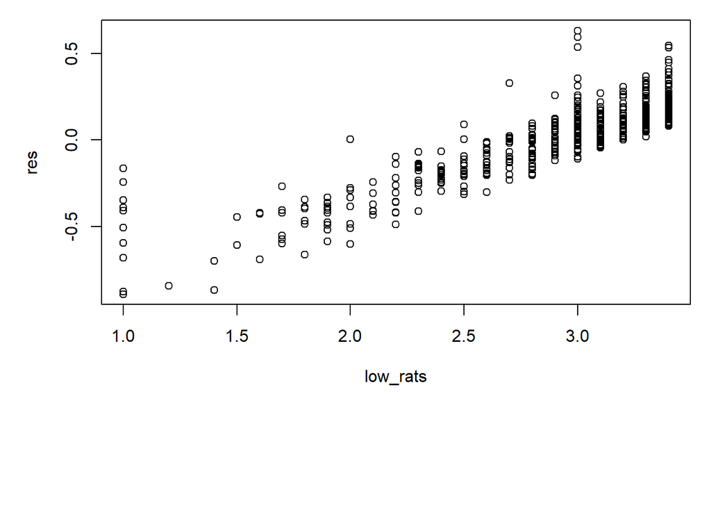

```r
res<-low_rats-preds_low
plot(low_rats,res)
```

## 13. CategoryCOMMUNICATION

## 14. CategoryDATING

## 15. CategoryFOOD_AND_DRINK

## 16. CategoryBUSINESS

## 17. CategoryPHOTOGRAPHY

## 18. CategoryNEWS_AND_MAGAZINES

## 19. Content.RatingTeen

## 20. CategoryGAME

```r
df<-data.frame(low_dummy)
low_top20<-df[c("Reviews", "Installs", "Size", "Current.Ver", "Android.Ver", "CategoryTOOLS", "CategoryFAMILY", "CategoryMEDICAL", "CategoryFINANCE", "Price", "CategoryLIFESTYLE", "CategoryHEALTH_AND_FITNESS", "CategoryCOMMUNICATION", "CategoryDATING", "CategoryFOOD_AND_DRINK", "CategoryBUSINESS", "CategoryPHOTOGRAPHY", "CategoryNEWS_AND_MAGAZINES", "Content.RatingTeen", "CategoryGAME")]

set.seed(452)

rf_Model_low<-randomForest(low_top20,low_rats, ntree=100, max_nodes = 1000, importance = T)

importance(rf_Model_low)
```

```
##                                %IncMSE IncNodePurity
## Reviews                    12.06811179    36.9913776
## Installs                    8.41304217    19.9659055
## Size                       -0.97219174    18.4838108
## Current.Ver                 0.88172975    17.8029729
## Android.Ver                 1.38344179     9.0313342
## CategoryTOOLS              -0.93696107     3.2762339
## CategoryFAMILY              2.01678749     2.5532485
## CategoryMEDICAL             1.90473906     3.0038487
## CategoryFINANCE            -0.03142761     2.8680399
## Price                       0.07399606     2.3995339
## CategoryLIFESTYLE           2.55136539     1.9268192
## CategoryHEALTH_AND_FITNESS  3.51738117     2.0175942
## CategoryCOMMUNICATION      -3.48642696     1.8168481
## CategoryDATING              2.35150836     1.7682949
## CategoryFOOD_AND_DRINK      2.80621644     1.3853961
## CategoryBUSINESS           -2.13676568     1.5760229
## CategoryPHOTOGRAPHY        -0.77613283     1.2843753
## CategoryNEWS_AND_MAGAZINES -0.23186304     1.1996320
## Content.RatingTeen          1.35203621     1.4307633
## CategoryGAME               -2.14955275     0.9976657
```

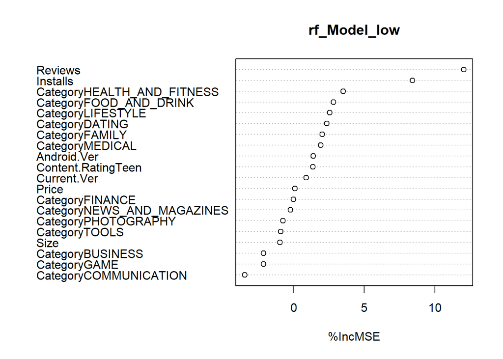

```r
varImpPlot(rf_Model_low, type = 1)
```

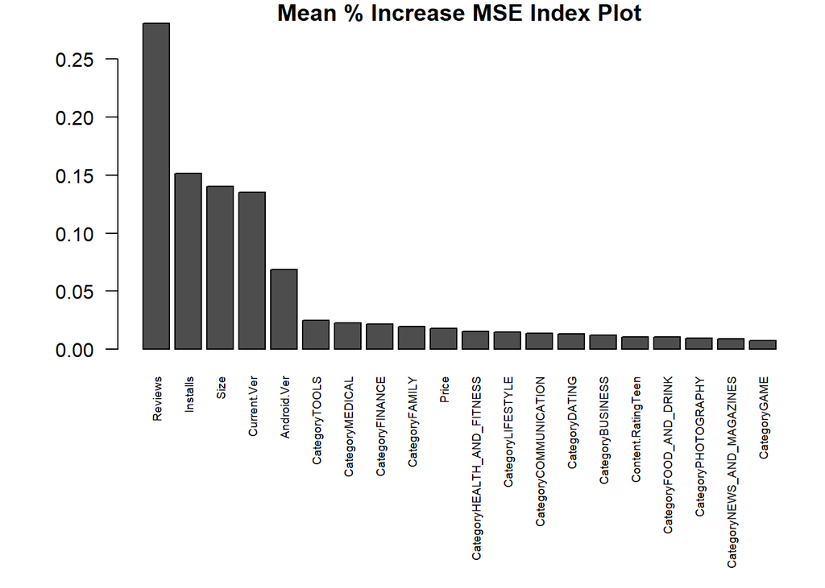

```r
var.imp1 <- data.frame(importance(rf_Model_low, type=2))
var.imp1$Variables <- row.names(var.imp1)
varimp1 <- var.imp1[order(var.imp1[1],decreasing = T),]
par(mar=c(10,5,1,1))
giniplot <- barplot(t(varimp1[-2]/sum(varimp1[-2])),las=2,
                     cex.names=0.6,
                    main="Mean % Increase MSE Index Plot")
```

```r
preds_low<- predict(rf_Model_low, low_dummy)

rmse(low_rats, preds_low)
```

```
## [1] 0.2487567
```

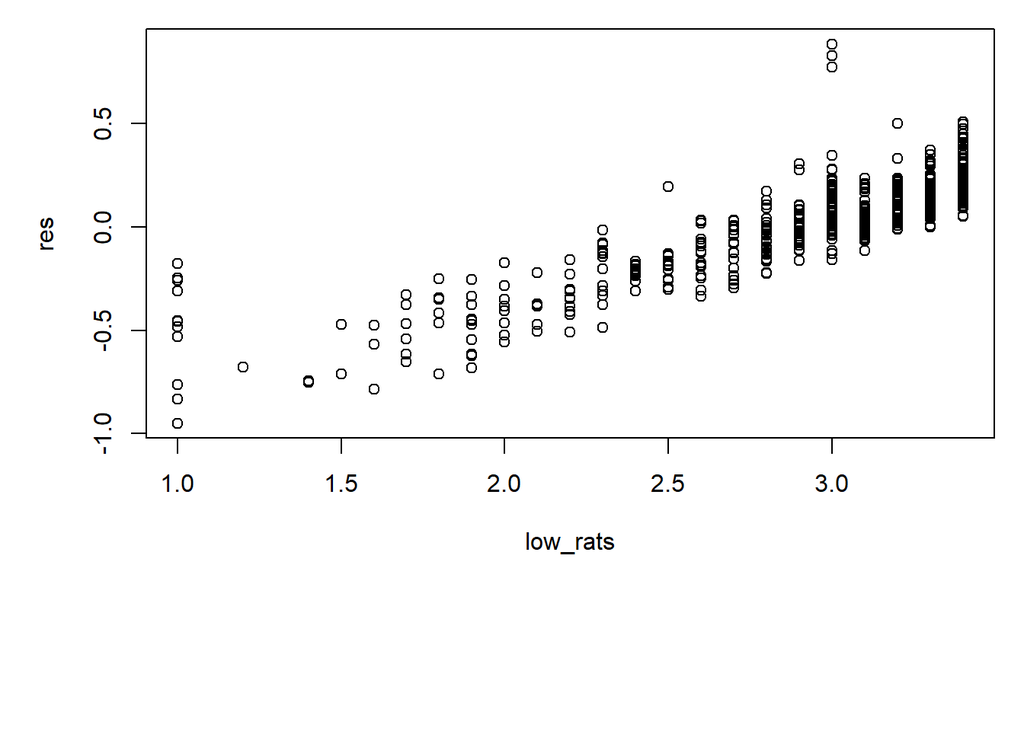

```r
res<-low_rats-preds_low
plot(low_rats,res)
```

## This looks good now we will do the same for the highly rated apps

```r
set.seed(742)

rf_Model_high<-randomForest(high_dummy,high_rats, ntree=100, max_nodes = 1000, importance = T)

importance(rf_Model_high)
```

```
##                                 %IncMSE IncNodePurity
## (Intercept)                  0.00000000  0.000000e+00
## CategoryAUTO_AND_VEHICLES    4.89436707  2.886586e+00
## CategoryBEAUTY               2.40805457  1.670904e+00
## CategoryBOOKS_AND_REFERENCE  5.42141699  4.116753e+00
## CategoryBUSINESS             2.49559475  4.560093e+00
## CategoryCOMICS              -1.47782103  1.920561e+00
## CategoryCOMMUNICATION        8.97160932  5.376905e+00
## CategoryDATING               5.17118150  2.842751e+00
## CategoryEDUCATION            4.96108886  2.191269e+00
## CategoryENTERTAINMENT        8.73009919  2.336140e+00
## CategoryEVENTS              -1.72178509  6.296603e-01
## CategoryFAMILY               4.72929986  9.266321e+00
## CategoryFINANCE              1.72548561  4.445087e+00
## CategoryFOOD_AND_DRINK       3.91092434  2.599875e+00
## CategoryGAME                 8.65753036  5.637464e+00
## CategoryHEALTH_AND_FITNESS   8.32655348  4.602198e+00
## CategoryHOUSE_AND_HOME      -0.01108602  1.377905e+00
## CategoryLIBRARIES_AND_DEMO   0.46786413  1.249790e+00
## CategoryLIFESTYLE            2.16587569  5.630585e+00
## CategoryMAPS_AND_NAVIGATION  3.59797828  3.031276e+00
## CategoryMEDICAL              2.73066574  5.172820e+00
## CategoryNEWS_AND_MAGAZINES   4.54183665  4.177216e+00
## CategoryPARENTING            2.54526690  1.503776e+00
## CategoryPERSONALIZATION      2.52503517  3.874075e+00
## CategoryPHOTOGRAPHY          2.14681242  2.846072e+00
## CategoryPRODUCTIVITY         0.47007862  3.677909e+00
## CategorySHOPPING             0.89742127  2.119356e+00
## CategorySOCIAL               4.18112960  3.248132e+00
## CategorySPORTS               5.97654606  6.073741e+00
## CategoryTOOLS                3.75280560  6.395718e+00
## CategoryTRAVEL_AND_LOCAL     4.99036579  3.124944e+00
## CategoryVIDEO_PLAYERS        5.60709959  2.995514e+00
## CategoryWEATHER             -1.76677139  1.375160e+00
## Reviews                     34.78848137  1.279260e+02
## Size                        14.83224727  6.990244e+01
## Installs                    34.69027310  8.304906e+01
## Price                       14.50820095  1.413833e+01
## Content.RatingEveryone       9.69398455  6.538721e+00
## Content.RatingEveryone 10+   3.24000732  2.797406e+00
## Content.RatingMature 17+     8.61515381  4.183226e+00
## Content.RatingTeen           7.29312232  4.945672e+00
## Content.RatingUnrated        0.00000000  4.537181e-03
## Current.Ver                  5.34297388  5.086620e+01
## Android.Ver                  7.18720946  3.388544e+01
## Days                        12.57258723  8.037696e+01
```

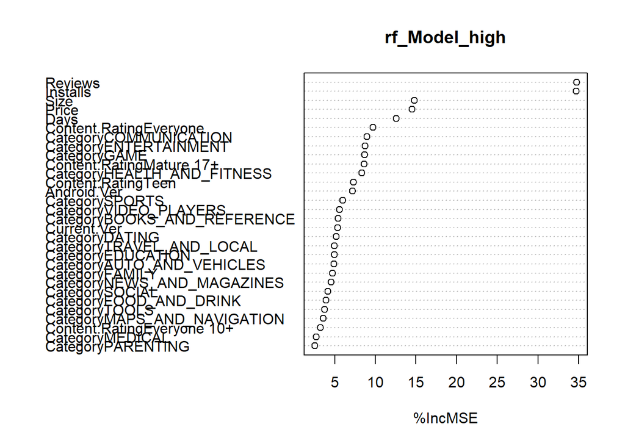

```r
varImpPlot(rf_Model_high, type = 1)
```

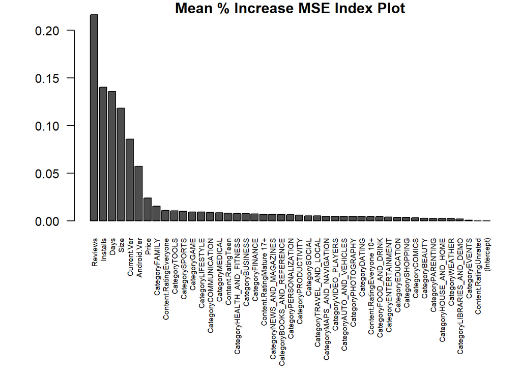

```r
var.imp1 <- data.frame(importance(rf_Model_high, type=2))
var.imp1$Variables <- row.names(var.imp1)
varimp1 <- var.imp1[order(var.imp1[1],decreasing = T),]
par(mar=c(10,5,1,1))
giniplot <- barplot(t(varimp1[-2]/sum(varimp1[-2])),las=2,
                     cex.names=0.6,
                    main="Mean % Increase MSE Index Plot")
```

```r
preds_high<- predict(rf_Model_high, high_dummy)

rmse(high_rats, preds_high)
```

```
## [1] 0.1345732
```

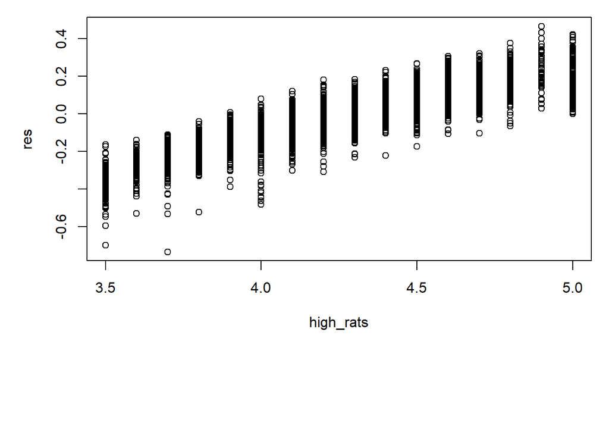

```r
res<-high_rats-preds_high
plot(high_rats,res)
```

### Top 20 high score predictors

## 1. Reviews

## 2. Installs

## 3. Size

## 4. Current.Ver

## 5. Android.Ver

## 6. Price

## 7. CategoryFAMILY

## 8. CategorySPORTS

## 9. CategoryLIFESTYLE

## 10. CategoryGAME

## 11. CategoryTOOLS

## 12. CategoryMEDICAL

## 13. CategoryBUSINESS

## 14. Content.RatingTeen

## 15. CategoryCOMMUNICATION

## 16. CategoryHEALTH_AND_FITNESS

## 17. CategoryFINANCE

## 18. CategoryNEWS_AND_MAGAZINES

## 19. Content.RatingMature 17+

## 20. CategoryPERSONALIZATION

```r
df<-data.frame(high_dummy)
high_top20<-df[c("Reviews", "Installs", "Size", "Current.Ver", "Android.Ver", "Price", "CategoryFAMILY", "CategorySPORTS", "CategoryLIFESTYLE", "CategoryGAME", "CategoryTOOLS", "CategoryMEDICAL", "CategoryBUSINESS", "Content.RatingTeen", "CategoryCOMMUNICATION", "CategoryHEALTH_AND_FITNESS", "CategoryFINANCE", "CategoryNEWS_AND_MAGAZINES", "Content.RatingMature.17.", "CategoryPERSONALIZATION")]

high_top20["Content.RatingMature 17+"]<-high_top20["Content.RatingMature.17."]

high_top20["Content.RatingMature.17."]<-NULL

rf_Model_high<-randomForest(high_top20,high_rats, ntree=100, max_nodes = 1000, importance = T)

importance(rf_Model_high)
```

```
##                              %IncMSE IncNodePurity
## Reviews                    43.232335    146.170398
## Installs                   45.871302     85.036209
## Size                       14.144557     86.163982
## Current.Ver                 5.788024     64.290797
## Android.Ver                11.428933     42.129957
## Price                      14.621927     15.292089
## CategoryFAMILY              6.239659      9.858776
## CategorySPORTS              6.383859      6.500348
## CategoryLIFESTYLE           2.734347      6.485546
## CategoryGAME                7.972458      6.452306
## CategoryTOOLS               4.773524      5.187538
## CategoryMEDICAL             4.803851      5.518998
## CategoryBUSINESS            3.226200      5.361113
## Content.RatingTeen          6.948992      8.716564
## CategoryCOMMUNICATION       7.273155      4.639964
## CategoryHEALTH_AND_FITNESS 11.941871      4.178294
## CategoryFINANCE             1.140697      5.210929
## CategoryNEWS_AND_MAGAZINES  5.436753      5.363151
## CategoryPERSONALIZATION     2.020522      4.182964
## Content.RatingMature 17+   10.482188      5.570744
```

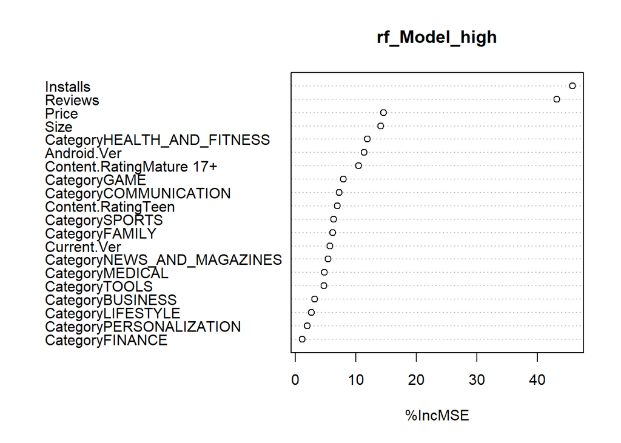

```r
varImpPlot(rf_Model_high, type = 1)
```

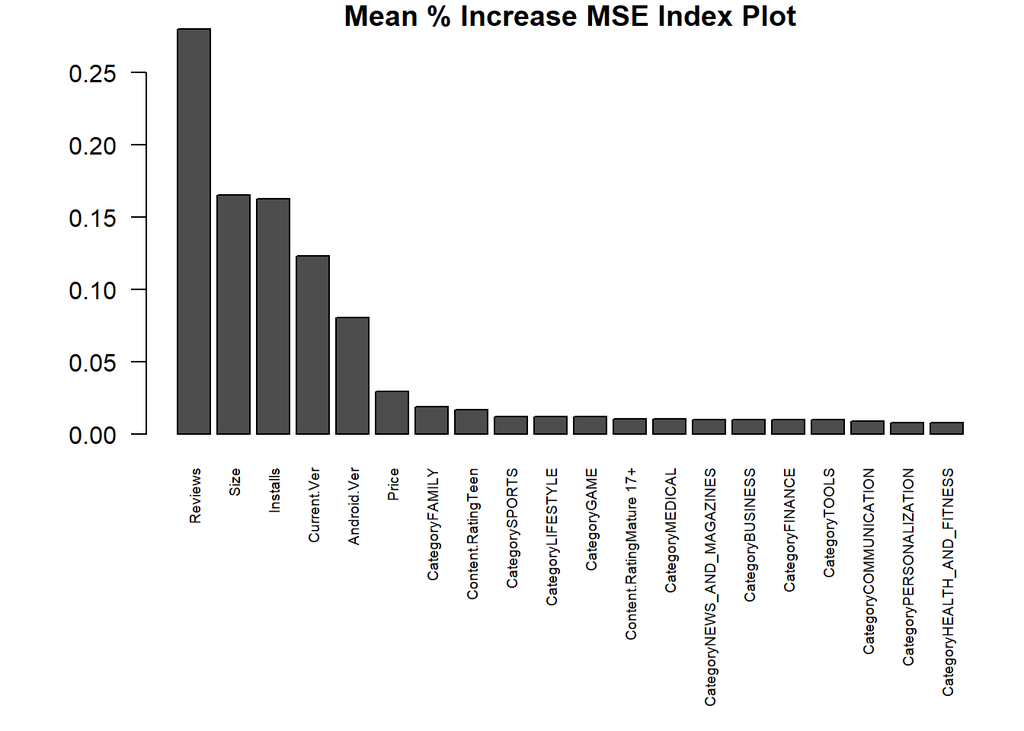

```r
var.imp1 <- data.frame(importance(rf_Model_high, type=2))
var.imp1$Variables <- row.names(var.imp1)
varimp1 <- var.imp1[order(var.imp1[1],decreasing = T),]
par(mar=c(10,5,1,1))
giniplot <- barplot(t(varimp1[-2]/sum(varimp1[-2])),las=2,
                     cex.names=0.6,
                    main="Mean % Increase MSE Index Plot")
```

```r
preds_high<- predict(rf_Model_high, high_dummy)

rmse(high_rats, preds_high)
```

```
## [1] 0.1637129
```

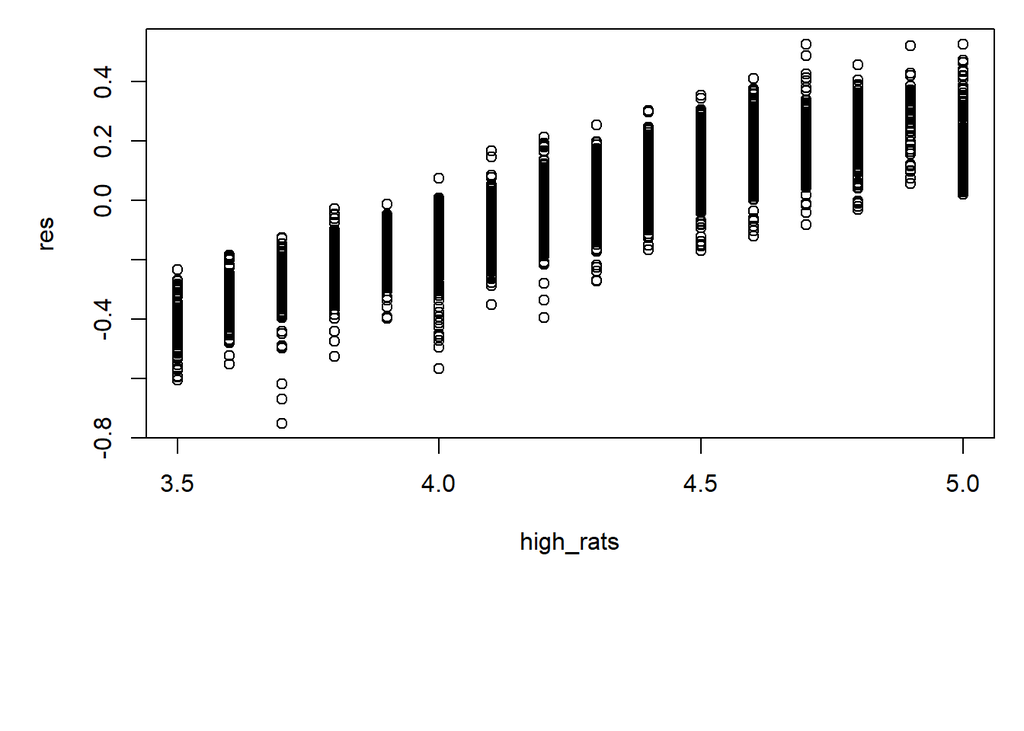

```r
res<-high_rats-preds_high
plot(high_rats,res)
```

# OK now the models are all set, but I realized 1 issue

## After the classifier makes an initial split in the data, almost all of the points with bad ratings are sent to the low model, but we also have points that are wrongly predicted as bad being sent to this model as well. I would like to have a chance of still predicting values larger than 3.5 on samples classified as bad, so I will build a third regressor which will be an intermediary step to get a predicted value on points initialy predicted as bad. After getting a preliminary rating I will pick a cutoff rating slightly higher than 3.5 so that we are likely to catch some incorrectly classified points (the cutoff will be higher than 3.5 because this classifier will be more prone to over-estimating)

## We do not need to do this for the high classified points as our initial classifier for popular apps is very pure for popular apps.

```r
bads<-which(clas_preds == "Bad")
int_dummy<-dummy_Train[bads,]
int_rats<-train_y[bads]

set.seed(99999)

rf_Model_int<-randomForest(int_dummy,int_rats, ntree=100, max_nodes = 1000, importance = T)

importance(rf_Model_int)
```

```
##                                 %IncMSE IncNodePurity
## (Intercept)                  0.00000000    0.00000000
## CategoryAUTO_AND_VEHICLES   -1.38385251    1.09236394
## CategoryBEAUTY               0.00000000    0.61719555
## CategoryBOOKS_AND_REFERENCE -0.02858991    1.34885938
## CategoryBUSINESS            -2.96043176    4.56108795
## CategoryCOMICS               0.96900589    0.81829097
## CategoryCOMMUNICATION       -2.25556010    2.13813359
## CategoryDATING              -0.00841010    2.17571688
## CategoryEDUCATION            0.00000000    0.00000000
## CategoryENTERTAINMENT       -1.27754419    1.19049815
## CategoryEVENTS               0.00000000    0.02886999
## CategoryFAMILY              -1.55424655    6.48789073
## CategoryFINANCE              1.30011531    4.74788271
## CategoryFOOD_AND_DRINK       2.67237417    4.70584186
## CategoryGAME                -1.30467869    0.88273717
## CategoryHEALTH_AND_FITNESS  -1.84359996    5.26620545
## CategoryHOUSE_AND_HOME       1.07092481    0.57364772
## CategoryLIBRARIES_AND_DEMO   0.00000000    0.02685279
## CategoryLIFESTYLE            3.41640482    4.02856734
## CategoryMAPS_AND_NAVIGATION  0.17665690    0.73669355
## CategoryMEDICAL              3.86964969    5.93736370
## CategoryNEWS_AND_MAGAZINES  -1.29217372    3.65269249
## CategoryPARENTING            5.16728066    5.41524657
## CategoryPERSONALIZATION      1.27072760    0.32440454
## CategoryPHOTOGRAPHY         -1.43581128    3.98939286
## CategoryPRODUCTIVITY         2.27916250    3.48082439
## CategorySHOPPING             0.01936564    2.74373852
## CategorySOCIAL              -0.59547218    1.52335169
## CategorySPORTS              -1.13561947    2.21564986
## CategoryTOOLS               11.97928011   32.02585087
## CategoryTRAVEL_AND_LOCAL    -1.27546425    1.45968891
## CategoryVIDEO_PLAYERS        0.03882780    2.03735483
## CategoryWEATHER              0.00000000    0.02138722
## Reviews                      4.86805158   72.46245309
## Size                         0.12907980   58.33704768
## Installs                     4.40183333   39.08152217
## Price                        0.86494380    4.24957850
## Content.RatingEveryone       1.43046127    2.81240854
## Content.RatingEveryone 10+   1.06746881    0.41503397
## Content.RatingMature 17+     2.23355434    2.29473014
## Content.RatingTeen           1.07869204    1.04715324
## Content.RatingUnrated        0.00000000    0.00000000
## Current.Ver                  2.14009744   55.09268480
## Android.Ver                  1.40697120   29.37317664
## Days                        -1.59766731   57.30851314
```

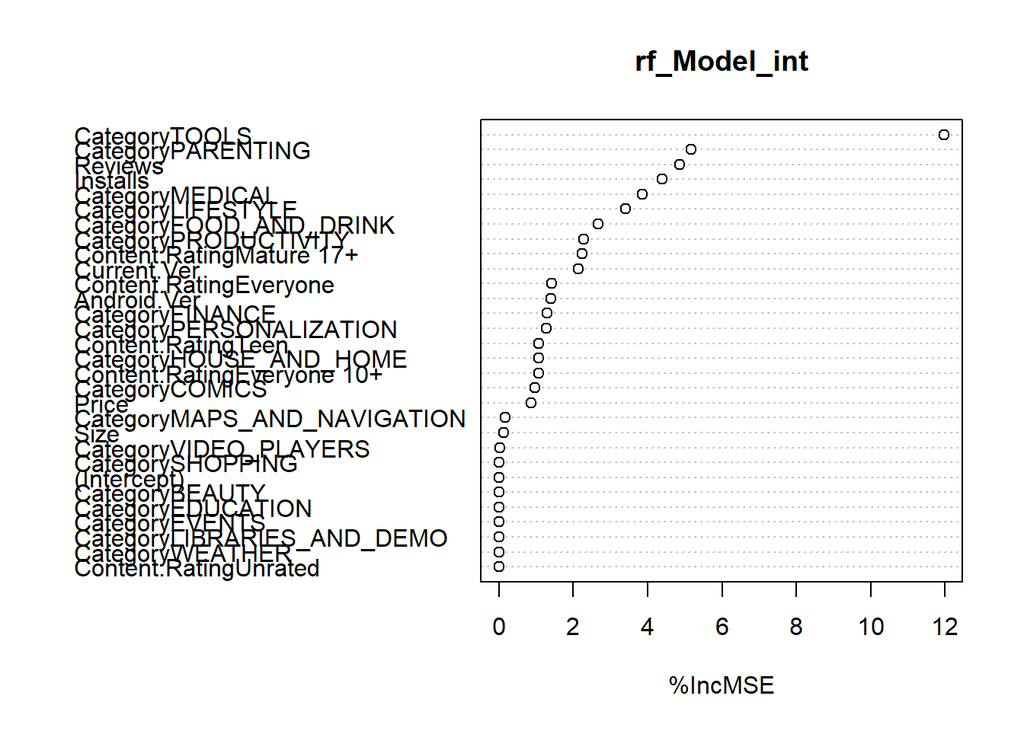

```r
varImpPlot(rf_Model_int, type = 1)
```

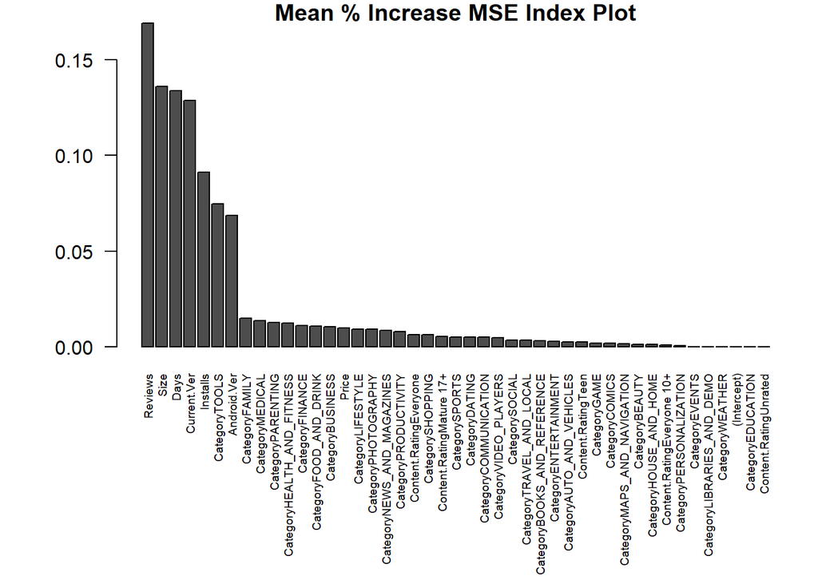

```r
var.imp1 <- data.frame(importance(rf_Model_int, type=2))
var.imp1$Variables <- row.names(var.imp1)
varimp1 <- var.imp1[order(var.imp1[1],decreasing = T),]
par(mar=c(10,5,1,1))
giniplot <- barplot(t(varimp1[-2]/sum(varimp1[-2])),las=2,
                     cex.names=0.6,
                    main="Mean % Increase MSE Index Plot")
```

```r
preds_int<- predict(rf_Model_int, int_dummy)

rmse(int_rats, preds_int)
```

```
## [1] 0.3817454
```

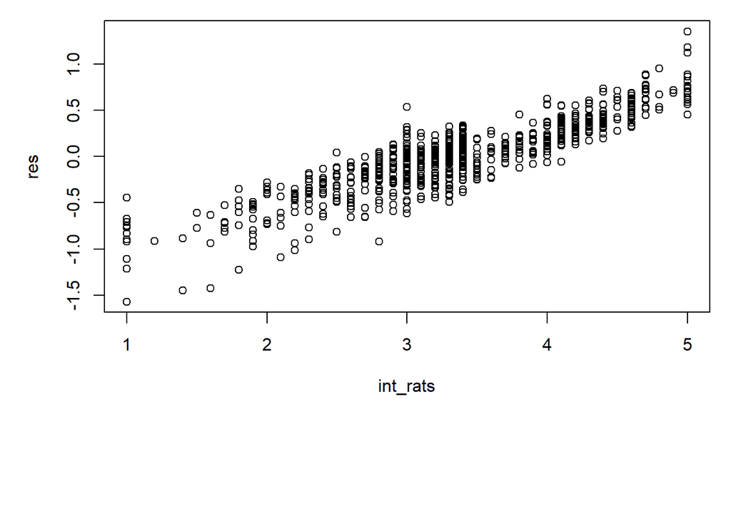

```r
res<-int_rats-preds_int
plot(int_rats,res)
```

## 7. CategoryTOOLS

## 8. CategoryHEALTH_AND_FITNESS

## 9. Price

## 10. CategoryMEDICAL

## 11. CategoryFINANCE

## 12. CategoryPHOTOGRAPHY

## 13. CategoryBUSINESS

## 14. CategoryLIFESTYLE

## 15. CategoryPRODUCTIVITY

## 16. CategoryFOOD_AND_DRINK

## 17. CategoryNEWS_AND_MAGAZINES

## 18. CategoryCOMMUNICATION

## 19. CategoryTRAVEL_AND_LOCAL

## 20. CategorySPORTS

```r
df<-data.frame(int_dummy)
int_top20<-df[c("Reviews","Size","Current.Ver","Installs","CategoryFAMILY","Android.Ver","CategoryTOOLS","CategoryHEALTH_AND_FITNESS","Price","CategoryMEDICAL","CategoryFINANCE","CategoryPHOTOGRAPHY","CategoryBUSINESS","CategoryLIFESTYLE","CategoryPRODUCTIVITY","CategoryFOOD_AND_DRINK","CategoryNEWS_AND_MAGAZINES","CategoryCOMMUNICATION","CategoryTRAVEL_AND_LOCAL","CategorySPORTS")]

rf_Model_int<-randomForest(int_top20,int_rats, ntree=100, max_nodes = 1000, importance = T)

importance(rf_Model_int)
```

```
##                               %IncMSE IncNodePurity
## Reviews                     4.9548009     88.979997
## Size                        1.9693372     67.935622
## Current.Ver                 1.5231843     60.434741
## Installs                    3.6678485     43.667707
## CategoryFAMILY             -2.8607236      7.142428
## Android.Ver                 0.9918113     33.169652
## CategoryTOOLS               9.1876756     29.525334
## CategoryHEALTH_AND_FITNESS -2.0116383      5.832630
## Price                       4.0677245      4.581694
## CategoryMEDICAL             3.6470841      7.822011
## CategoryFINANCE             2.5803370      5.969477
## CategoryPHOTOGRAPHY        -0.2172965      3.683903
## CategoryBUSINESS           -3.3408977      6.069849
## CategoryLIFESTYLE           5.7288761      4.781085
## CategoryPRODUCTIVITY        2.9864947      3.911751
## CategoryFOOD_AND_DRINK      0.9388146      5.076433
## CategoryNEWS_AND_MAGAZINES -1.0009227      4.615373
## CategoryCOMMUNICATION      -2.5435604      2.708353
## CategoryTRAVEL_AND_LOCAL   -0.5169759      1.481279
## CategorySPORTS             -2.4510650      2.962645
```

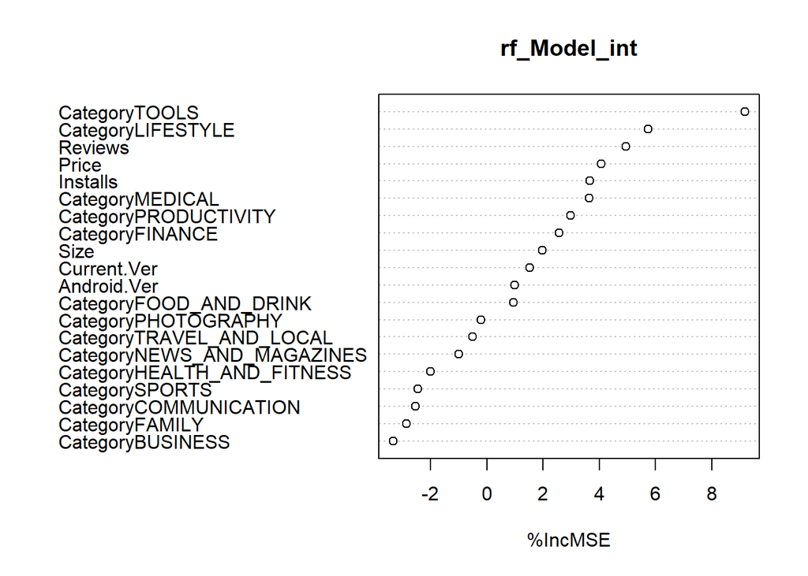

```r
varImpPlot(rf_Model_int, type = 1)
```

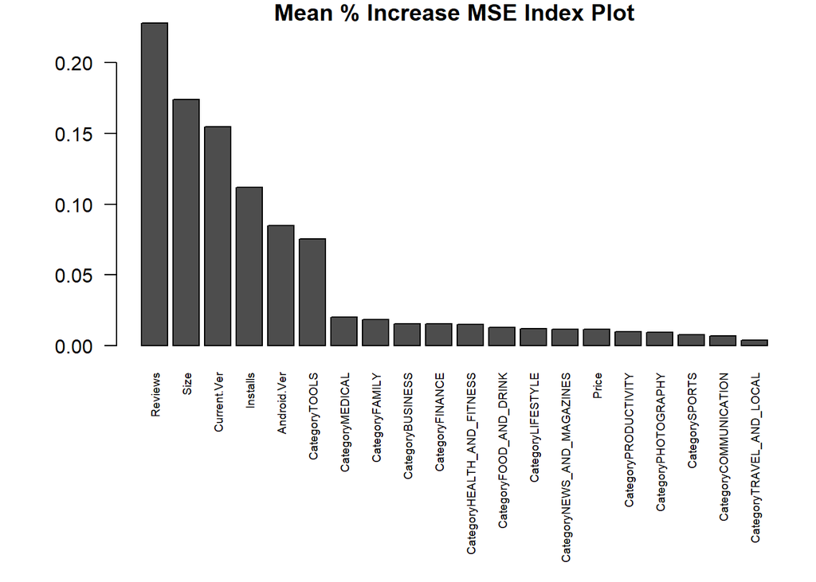

```r
var.imp1 <- data.frame(importance(rf_Model_int, type=2))
var.imp1$Variables <- row.names(var.imp1)
varimp1 <- var.imp1[order(var.imp1[1],decreasing = T),]
par(mar=c(10,5,1,1))
giniplot <- barplot(t(varimp1[-2]/sum(varimp1[-2])),las=2,
                     cex.names=0.6,
                    main="Mean % Increase MSE Index Plot")
```

```r
preds_int<- predict(rf_Model_int, int_dummy)

rmse(int_rats, preds_int)
```

```
## [1] 0.435765
```

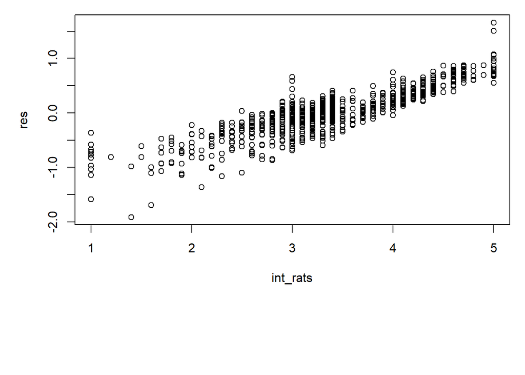

```r
res<-int_rats-preds_int
plot(int_rats,res)
```